# Bank branch closures in the UK - 2010-2023

Sylvia Gottschalk

2025-11-05

## Introduction

We show how to map the reduction of the number of bank branches in the UK between 2010 and 2023. The data are collected by the Office for National Statistics (ONS) and published by NOMIS, an ONS service that publishes statistics related to population, society and the labour market at national, regional and local levels. The database from which the data presented here were taken is the UK Business counts, compiled from the Inter-Departmental Business Register (IDBR) for all years from 2010. The dataset captures the number of local units active as of the reference date in March. A local unit refers to an individual site—such as a factory or shop—linked to an enterprise (in this case, a financial service or intermediary). Statistics are classified by employment size band, detailed industry (5-digit SIC 2007), and legal status. Geographic coverage ranges from national level down to mid-layer super output areas (MLSOAs) and Scottish intermediate zones.

## Load the libraries

```r
library(tidyverse)
#library(tmap)
#library(ggplot2)
library(sf)
```

Tidyverse is a collection of packages that are used in data analyses, such as ggplot2 -to draw graphics; dplyr for data manipulation; tidyr tidying data; and readr for reading rectangular data such as csv.

sf is a package that helps with the creation of maps. “sf” stands for simple feature which “refers to a formal standard (ISO 19125-1:2004) that describes how objects in the real world can be represented in computers, with emphasis on the spatial geometry of these objects. It also describes how such objects can be stored in and retrieved from databases, and which geometrical operations should be defined for them.” (https://r-spatial.github.io/sf/articles/sf1.html)

## Load data

We first upload a shapefile, i.e., a file that contains the map of the UK, and specifically the UK regions.This shapefile contains the digital vector boundaries for Nomenclature of Territorial Units for Statistics Level 1 (NUTS1), in the United Kingdom, as of January 2018.

Details of the file can be found on https://ons.maps.arcgis.com/home/item.html?id=772135bc779649c49357dfcf6888a174&sublayer=0#data

```r
UK_regions<-st_read("C:/Users/sylvia5/Documents/R_codes/lsbs/NUTS1_UK/NUTS_Level_1_January_2018_FEB_in_the_United_Kingdom.shp")
SIC64191_units_10<- read.csv("sic64191_NUTS1_2010.csv", sep=",", header=T)
```

In addition to the map of UK regions, we upload data on the number of bank branches by region of the UK. The bank branches are defined here as a business unit of the SIC sector Financial and Insurance Activities -Division 64: Financial service activities, except insurance and pension funding; Group 64.1: Monetary intermediation; Class 64.19: Other monetary intermediation; Sub-class 64.19/1: Banks. The data are available from 2010.

After loading both files, the map and data are merged into a single dataframe.

```r
region_filter <- merge(x=UK_regions,y=SIC64191_units_10, by = "nuts118nm")
```

This dataframe is then used as the source of the data in the plots.

## Plot the data

We will plot two maps presenting the number of bank branches by UK regions in 2010 and 2023. For the year 2010

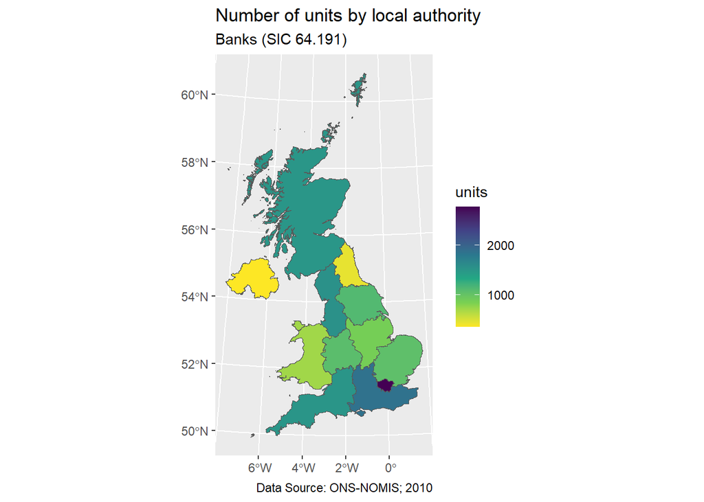

```r
map_2010<-ggplot(region_filter) +
  geom_sf(aes(fill = units))+
  scale_fill_viridis_c(direction = -1) +
  labs(title = "Number of units by local authority",
       subtitle = "Banks (SIC 64.191)",
       caption = "Data Source: ONS-NOMIS; 2010")

plot(map_2010)
```

The colours indicate the density of business units by geographical locations. Repeating for 2023

```r
SIC64191_units_23<- read.csv("sic64191_NUTS1_2023.csv", sep=",", header=T)
region_filter <- merge(x=UK_regions,y=SIC64191_units_23, by = "nuts118nm")
```

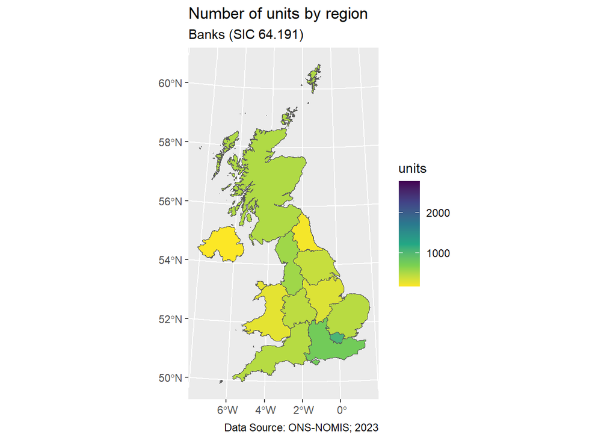

```r
map_2023<-ggplot(region_filter) +
  geom_sf(aes(fill = units))+
  scale_fill_viridis_c(direction = -1,limits = c(180, 2780)) +
  labs(title = "Number of units by region",
       subtitle = "Banks (SIC 64.191)",
       caption = "Data Source: ONS-NOMIS; 2023")
plot(map_2023)
```

The maps clearly show a sharp reduction in the number of bank branches across the UK. The first map shows that in 2010 the highest number of bank branches could be found in London (2,770 branches) and South East England (1,865 branches), followed by North West England (1,550 branches), South West England (1,515) and Scotland (1,505). The remaining regions had all less than 1,000 bank branches in 2010, with the lowest density in Northern Ireland (360 branches).

The unequal regional distribution of bank branches remained to a large extent in 2023, viz., London and the South East England were the two regions with the largest number of branches (1,055 and 770, resp.) in 2023. North West England and Scotland had 570 and 505 branches, respectively, but all remaining regions had less than 500 bank branches.

## References

Gottschalk, S., R. Owen, and I. Coban (2024) Are English SMEs disadvantaged in accessing Green Finance? A study of UK (bank and non-bank) debt finance provision. London: Middlesex University. https://cusp.ac.uk/themes/finance/report-mdx-greenfin-smes/